# Tumor-osteosarcoma interactions during metastatic colonization of the lung

Author

Ryan Roberts, Matthew Cannon, James Reinecke

Published

May 7, 2025

# Download and organize the public data used in this analysis

# Load published data from GSE152048

If not already done, download the data sets from the GEO repository, extract matrices, import into a Seurat object, perform initial QC and append relevant clinical data for each sample, as reported in the manuscript.

```r
# Make a list of sample names
geo1 <- tibble(
  name = c("X00003", "X00004", "X00005", "X00006", "X00007", "X00008",
    "X00010", "X00009", "X00011"),
  model = c("BC5", "BC6", "BC10", "BC11", "BC16",
    "BC17", "BC20", "BC21", "BC22"),
  qc = c(18000, 25000, 25000, 30000, 70000,
    40000, 70000, 50000, 50000),
  path = c("Conventional", "Conventional", "Conventional",
    "Conventional", "Conventional", "Chondroblastic",
    "Chondroblastic", "Intraosseous", "Chondroblastic"),
  type = c("Primary", "Primary", "Lung Met", "Primary", "Primary",
          "Lung Met", "Primary", "Primary", "Primary")
)

# Check if primary tumor directory exists and create if it doesn't
if(!dir.exists("public")) {
  tar_dir <- "public"
  dir.create(tar_dir)
}

# Download, extract, and organize the files from GEO
if(!dir.exists("public/GSE152048")) {
  tar_dir <- "public/GSE152048"
  dir.create(tar_dir)
  geo_pre <- "https://ftp.ncbi.nlm.nih.gov/geo/series/GSE152nnn/GSE152048/suppl/GSE152048_"
  for(s in geo1$model){
    gse_path <- paste0(geo_pre, s, ".matrix.tar.gz")
    tar_file <- paste0(tar_dir, "/", s, ".tar.gz ")
    download.file(gse_path, destfile = tar_file, method = "auto")
    untar(tar_file, exdir = tar_dir)
    file.remove(tar_file)
  }
}

# Create a vector of normalized Seurat objects for all GSE152048 samples
human_geo <- future_lapply(geo1$model, function(s) {
  raw <- tenx_load_qc(paste0("public/GSE152048/",
                          s, "/"))
  raw <- subset(raw, subset = nCount_RNA < geo1$qc[geo1$model == s] & percent.mt <13)
  raw$src <- s
  raw$name <- geo1$name[geo1$model == s]
  raw$type <- geo1$type[geo1$model == s]
  raw$path <- geo1$path[geo1$model == s]
  raw$gse <- "GSE152048"
  raw <- raw %>%
    NormalizeData()
  return(raw)
})

human_geo <- merge(human_geo[[1]], human_geo[2:length(human_geo)],
    add.cell.ids = geo1$name) %>%
    JoinLayers()

qs::qsave(human_geo, "output/seurat_objects/human_geo.qs")
```

# Co-culture experiments and NicheNET analysis

This script is organized generally into a series of subscripts that will process the raw data to generate figure panels as they are organized in the manuscript. The first of these will pull data from cell culture data–tumor cells and lung epithelial cells cultured either alone or together. This data will facilitate a ligand-receptor-target analysis designed to identify the mediators of the host-to-tumor interaction.

## NicheNET analysis

Starting with tumor (OS-17) and lung (HBEC) cells cultured either as monocultures or co-cultures, leverage the NicheNET algorithm to ask the question:

What ligands produced by epithelial cells would bind receptors in osteosarcoma cells to cause the target gene changes that are observed in the co-culture?

### Load and organize the co-culture data

```r
# scrna_path <- "../../../Counts_2/"
scrna_path <- "C:/Users/rxr014/OneDrive - Nationwide Children's Hospital/BIScratch/"

deets_cocx <- tribble(
    ~id, ~max_count, ~max_percent_mt, ~file,
    "S0001", 16000, 14, "S0001",
    "S0005", 16000, 14, "S0005")

cocx <- future_lapply(seq_len(nrow(deets_cocx)), function(i) {
    test <- tenx_load_qc(paste0(scrna_path,
                        deets_cocx$file[i],
                        "/filtered_feature_bc_matrix/"),
                 violin_plot = FALSE) %>%
        subset(nCount_RNA < deets_cocx$max_count[i] &
                   percent.mt < deets_cocx$max_percent_mt[i]) %>%
        process_seurat()
})

names(cocx) <- deets_cocx$id
for (i in seq_along(cocx)) {
    cocx[[i]]$src <- deets_cocx$id[i]
}
```

### Intercellular signaling analysis on co-culture data

Which signals produced by lung epithelial cells elicit the transcriptional changes that we see in osteosarcoma cells in co-culture? In NicheNET, define the target gene set by DEG analysis comparing osteosarcoma cells in co-culture to cultured alone. Define senders as the epithelial cells and receivers as the osteosarcoma cells.

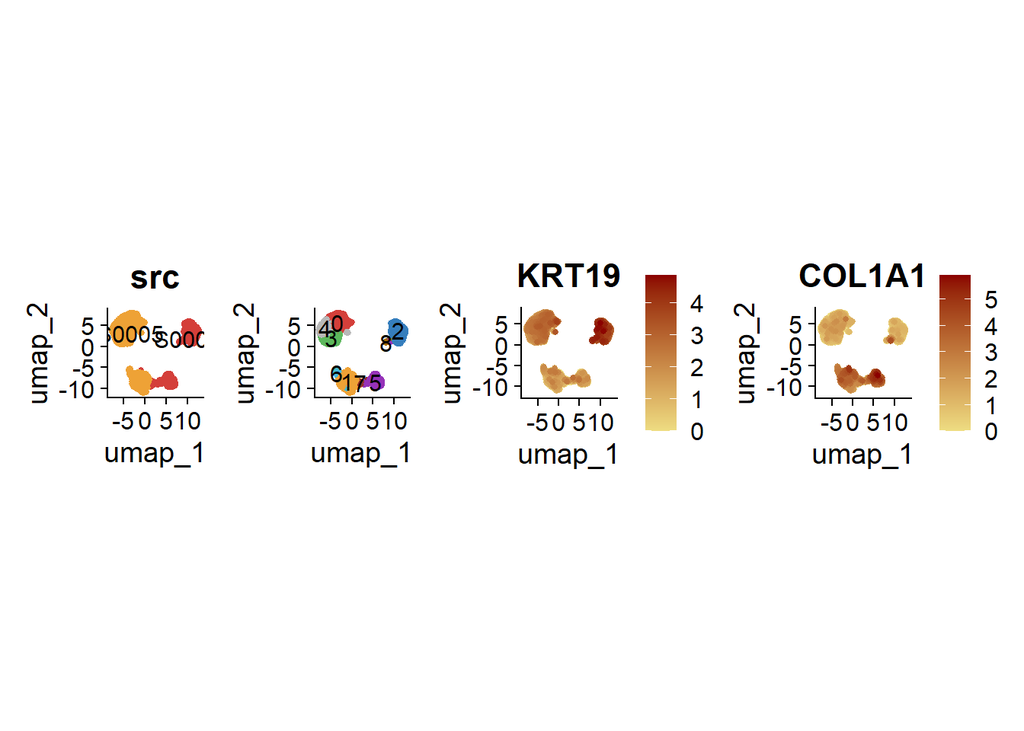

```r
cx <- merge(
    cocx$S0001,
    y = cocx$S0005,
    add.cell.ids = c("monocx", "cocx"),
    project = "InterSignaling") %>%
    JoinLayers()

cx <- process_seurat(cx, resolution  = 0.4)

p1 <- r_dim_plot(cx,
    group.by = "src",
    title = "Source")
p2 <- r_dim_plot(cx, "Clusters")
p3 <- r_feature_plot(cx, features = "KRT19", title = "KRT19")
p4 <- r_feature_plot(cx, features = "COL1A1", title = "COL1A1")

p <- p1 | p2 | p3 | p4
p
```

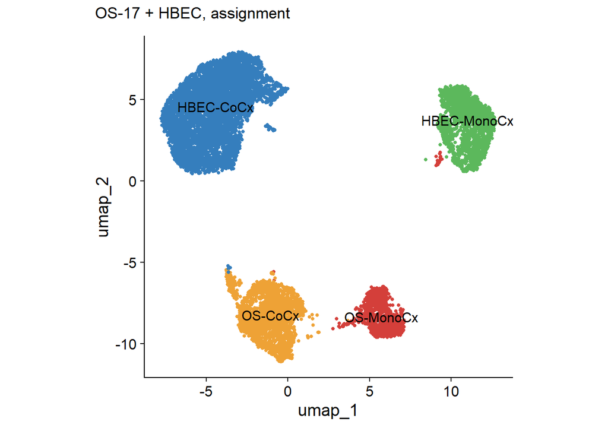

```r
stash_plot(p, "Co-culture")

# Suspect that clusters 7 and 8 are groups of doublets, remove
cx <- subset(cx, idents = c(7, 8), invert = T)

cx <- RenameIdents(cx,
    `5` = "OS-MonoCx",
    `1` = "OS-CoCx", `6` = "OS-CoCx",
    `0` = "HBEC-CoCx", `3` = "HBEC-CoCx", `4` = "HBEC-CoCx",
    `2` = "HBEC-MonoCx")

p <- r_dim_plot(cx, title = "OS-17 + HBEC, assignment")
p
```

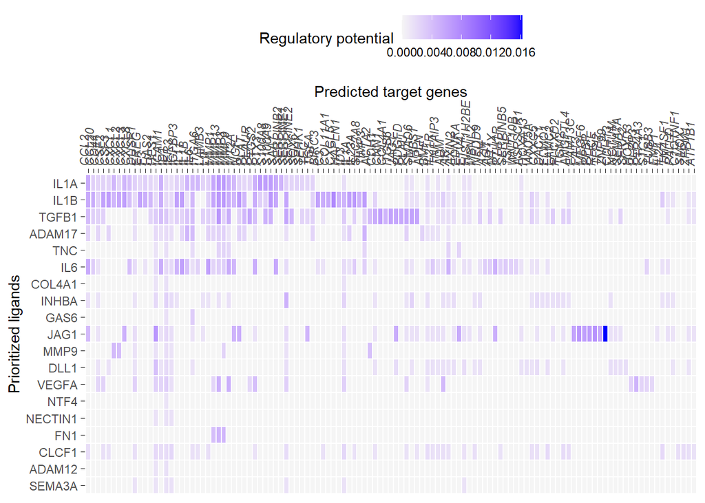

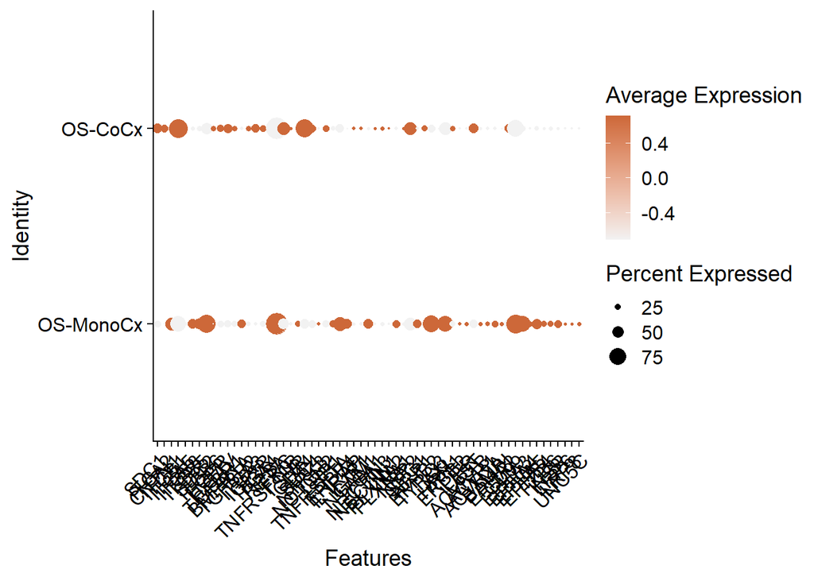

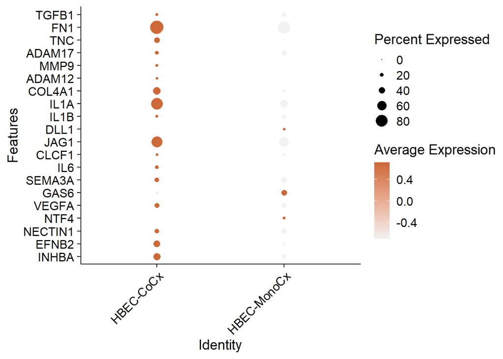

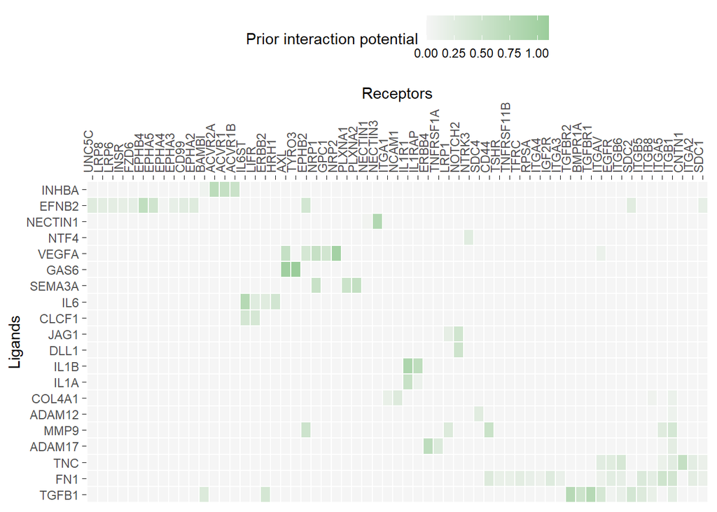

```r
stash_plot(p, "CoCx_assignments")

# Save off the processed Seurat object
qs::qsave(cx, "output/seurat_objects/cx.qs")

target_genes <- find_tar_genes(cx,
    id1 = "OS-CoCx",
    id2 = "OS-MonoCx",
    logfc = 2)

LRT_analysis_1 <- find_ligands(cx,
    target_genes,
    senders = c("HBEC-CoCx", "HBEC-MonoCx"),
    receiver = c("OS-CoCx", "OS-MonoCx"),
    rec_pct = 0.07,
    stringency = "strict")
```

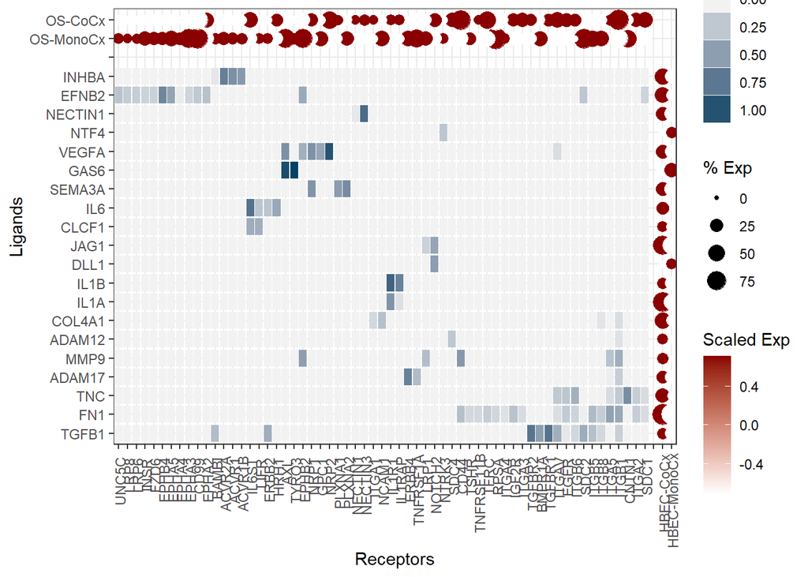

```r
p <- plot_complex_heatmap(LRT_analysis_1,
    grid_color_high = "#004466")
p
```

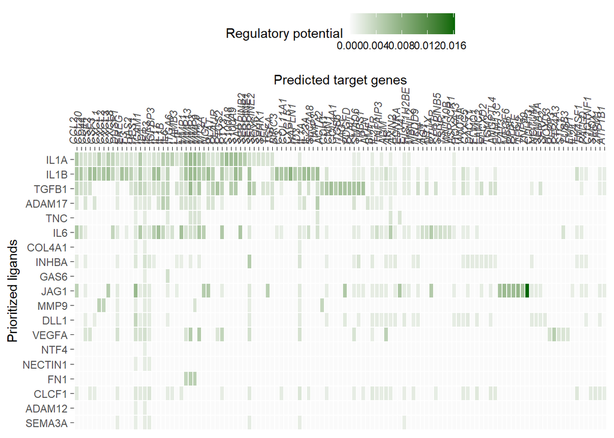

```r
stash_plot(p, "Nichenet_heatmap")

p <- LRT_analysis_1[[3]] +
    scale_fill_gradient(low = "gray98", high = "#006600")
p
```

```r
stash_plot(p, "Nichenet_targets")
```

### Evaluate changes in the production of ligands with co-culture

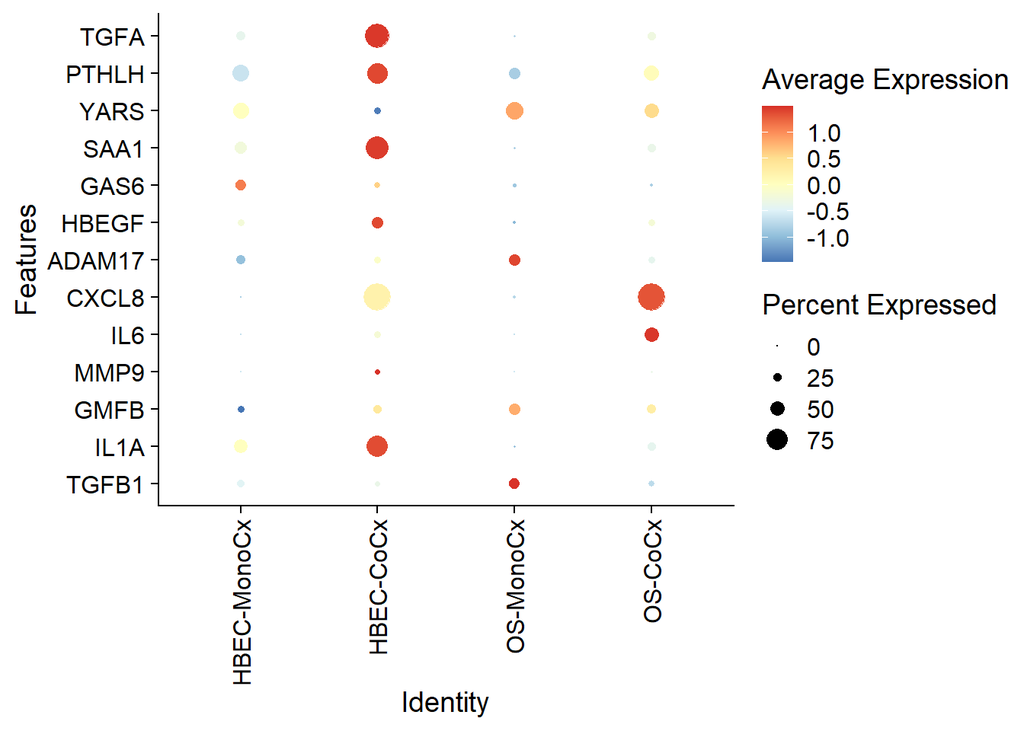

```r
ligands <- c(
    "TGFB1",
    "IL1A",
    "GMFB",
    "MMP9",
    "IL6",
    "CXCL8",
    "ADAM17",
    "HBEGF",
    "GAS6",
    "SAA1",
    "YARS",
    "PTHLH",
    "TGFA"
)

cx$assignment <- Idents(cx)
cx$assignment <- cx$assignment %>%
    factor(levels = c(
        "HBEC-MonoCx",
        "HBEC-CoCx",
        "OS-MonoCx",
        "OS-CoCx"
    ))

p <- DotPlot(cx, ligands, cols = "RdYlBu", group.by = "assignment") +
    coord_flip() +
    theme(axis.text.x = element_text(angle = 90, vjust = 0.5, hjust = 1))
p
```

```r
stash_plot(p, "Co-cx_dotplot")
```

# Evaluate intratumoral heterogeneity in relation to paracrine signals

This script assesses patterns of gene expression within tumor cell subpopulations isolated from PDX models and human patients.

## Heterogeneity analysis

### Isolate the co-culture tumor and evaluate IL6 and CXCL8 expression

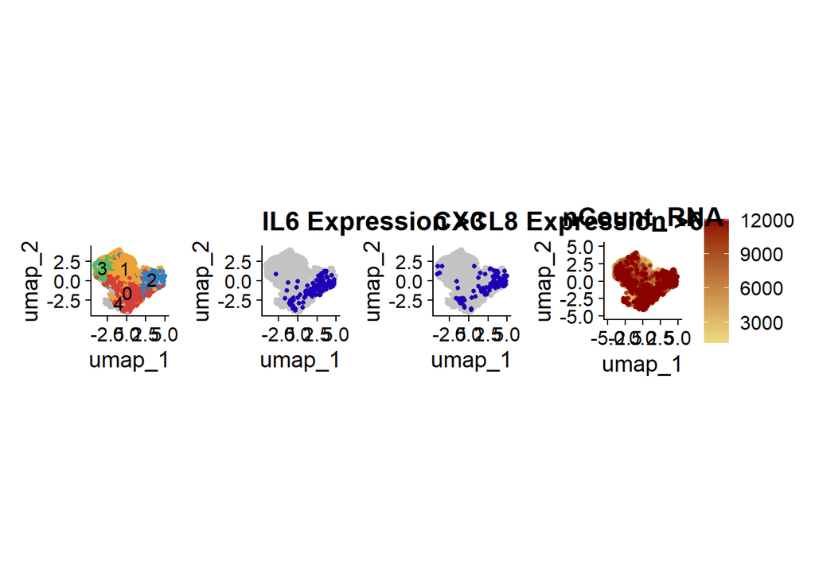

```r
# Load the processed culture data
cx <- qs::qread("output/seurat_objects/cx.qs")
tumor_cocx <- subset(cx, idents = "OS-CoCx")

# Remove the doublets that express epithelial markers
tumor_cocx <- subset(tumor_cocx, cells = readRDS("misc/doublets.rds"), invert = T)

tumor_cocx <- tumor_cocx %>%
    FindVariableFeatures() %>%
    RunPCA() %>%
    RunUMAP(
        dims = 1:20,
        n.neighbors = 20,
        min.dist = 0.1,
        local.connectivity = 5,
        spread = 1,
        verbose = FALSE) %>%
    FindNeighbors(verbose = FALSE) %>%
    FindClusters(verbose = FALSE, resolution = 0.25)

p1 <- r_dim_plot(tumor_cocx,
    title = "Tumor in Co-culture")
p2 <- DimPlot(tumor_cocx,
        cells.highlight = WhichCells(tumor_cocx, expression = IL6 > 3),
        cols.highlight = "#1F00B8",
        pt.size = 1) +
    labs(title = "IL6 Expression >3") +
    theme(legend.position = "none") +
    coord_fixed()
p3 <- DimPlot(tumor_cocx,
        cells.highlight = WhichCells(tumor_cocx, expression = CXCL8 > 6),
        cols.highlight = "#1F00B8",
        pt.size = 1) +
    labs(title = "CXCL8 Expression >6") +
    theme(legend.position = "none") +
    coord_fixed()
p4 <- r_feature_plot(tumor_cocx,
    "nCount_RNA",
    title = "Total Counts",
    max.cutoff = 12000)

p <- p1 | p2 | p3 | p4
p
```

```r
stash_plot(p, "Hetero-1")

qs::qsave(tumor_cocx, "output/seurat_objects/tumor_cocx.qs")
rm(tumor_cocx)
```

### Load human met scRNA-seq and create Seurat objects

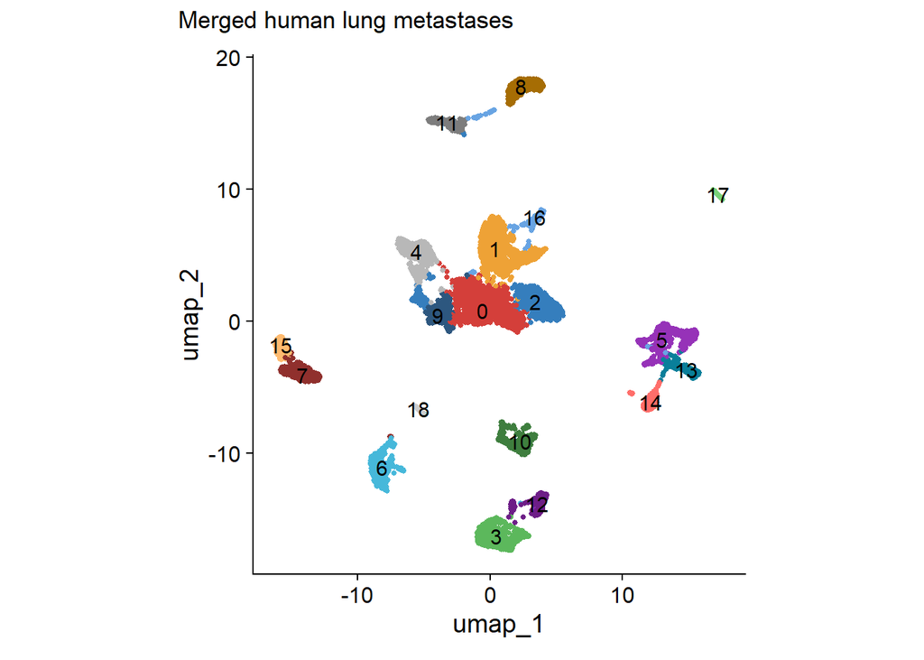

```r
# pre_path <- "~/../lab/Counts_2/"
pre_path <- "C:/Users/rxr014/OneDrive - Nationwide Children's Hospital/BIScratch/"
post_path <- "/filtered_feature_bc_matrix"

deets_mets <- tribble(
    ~id, ~max_count, ~max_percent_mt, ~src,
    "S0058", 50000, 14, "met-1",
    "S0059", 50000, 14, "met-2")

mets <- future_lapply(seq_len(nrow(deets_mets)), function(i) {
    s <- tenx_load_qc(paste0(pre_path,
                deets_mets$id[i],
                "/filtered_feature_bc_matrix/"),
            violin_plot = FALSE) %>%
        subset(
            nCount_RNA < deets_mets$max_count[i] &
            percent.mt < deets_mets$max_percent_mt[i]) %>%
        process_seurat()
})
names(mets) <- deets_mets$id
for (i in seq_along(mets)) {
    mets[[i]]$src <- deets_mets$src[i]
}

mets <- merge(mets[[1]], mets[[2:length(mets)]],
    add.cell.ids = deets_mets$id) %>%
    process_seurat()
mets$tumor <- "stroma"
mets$tumor[names(mets$tumor) %in% readRDS("misc/tumor_cells.rds")] <- "tumor"

r_dim_plot(mets, "Merged human lung metastases")
```

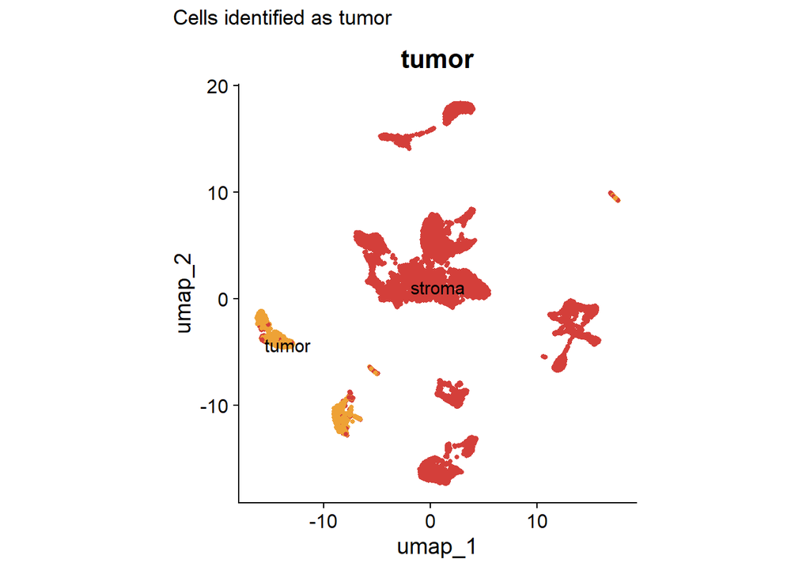

```r
r_dim_plot(mets, group.by = "tumor", "Cells identified as tumor")
```

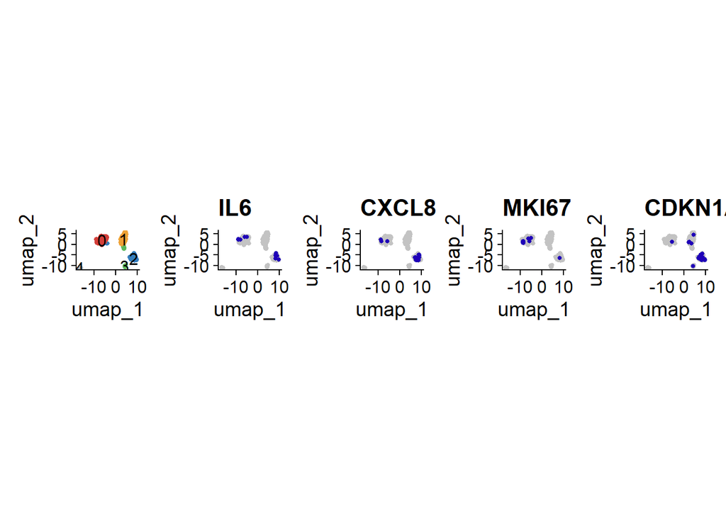

```r
mets_tumor <- subset(mets, tumor == "tumor") %>%
    process_seurat()

p1 <- r_dim_plot(mets_tumor, "Isolated tumor cells")
p2 <- DimPlot(mets_tumor,
        cells.highlight = WhichCells(mets_tumor, expression = IL6 > 0),
        cols.highlight = "#1F00B8",
        pt.size = 1) +
    labs(title = "IL6") +
    theme(legend.position = "none") +
    coord_fixed()
p3 <- DimPlot(mets_tumor,
        cells.highlight = WhichCells(mets_tumor, expression = CXCL8 > 1),
        cols.highlight = "#1F00B8",
        pt.size = 1) +
    labs(title = "CXCL8") +
    theme(legend.position = "none") +
    coord_fixed()
p4 <- DimPlot(mets_tumor,
        cells.highlight = WhichCells(mets_tumor, expression = MKI67 > 1),
        cols.highlight = "#1F00B8",
        pt.size = 1) +
    labs(title = "MKI67") +
    theme(legend.position = "none") +
    coord_fixed()
p5 <- DimPlot(mets_tumor,
        cells.highlight = WhichCells(mets_tumor, expression = CDKN1A > 1.5),
        cols.highlight = "#1F00B8",
        pt.size = 1) +
    labs(title = "CDKN1A") +
    theme(legend.position = "none") +
    coord_fixed()

p <- p1 | p2 | p3 | p4 | p5
p
```

```r
stash_plot(p, "Hetero-2")

qs::qsave(mets, "output/seurat_objects/mets.qs")
rm(mets)
```

### Intratumoral Heterogeneity - PDX Primary

```r
samples <- tribble(
  ~id, ~model, ~mt_cutoff, ~count_cutoff, ~species,
  "S0037", "OS-17", 25, 160000, "^GRCh38-"
)

s <- 1
pdx_tibia <- tenx_load_qc(
    paste0(pre_path, samples$id[s], post_path),
    species_pattern = samples$species[s],
    violin_plot = FALSE
  ) %>%
  subset(
    percent.mt < samples$mt_cutoff[s] &
    nCount_RNA < samples$count_cutoff[s]
  ) %>%
  NormalizeData()
pdx_tibia$id <- samples$id[s]
pdx_tibia$model <- samples$model[s]

pdx_tibia <- pdx_tibia %>%
  FindVariableFeatures(nfeatures = 5000) %>%
  ScaleData() %>%
  RunPCA()

pdx_tibia <- pdx_tibia %>%
  FindNeighbors(reduction = "pca", k.param = 200L) %>%
  FindClusters(resolution = 0.8) %>%
  RunUMAP(reduction = "pca", dims = 1:30)
```

```
Modularity Optimizer version 1.3.0 by Ludo Waltman and Nees Jan van Eck

Number of nodes: 3569
Number of edges: 1193895

Running Louvain algorithm...
Maximum modularity in 10 random starts: 0.6385
Number of communities: 5
Elapsed time: 1 seconds
```

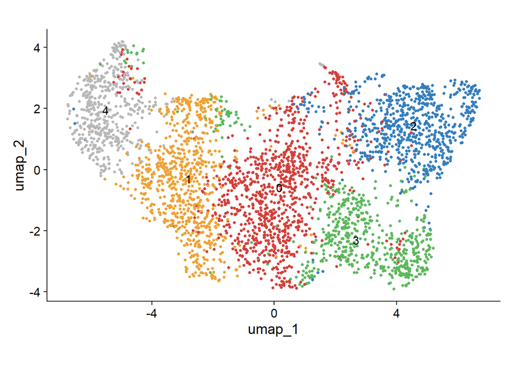

```r
r_dim_plot(pdx_tibia)
```

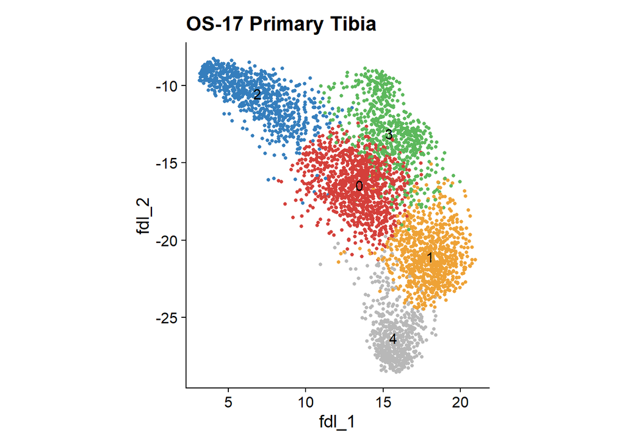

```r
pdx_tibia <- run_fdl(pdx_tibia)

p1 <- r_dim_plot(pdx_tibia, reduction = "fdl") +
  labs(title = "OS-17 Primary Tibia")
p1
```

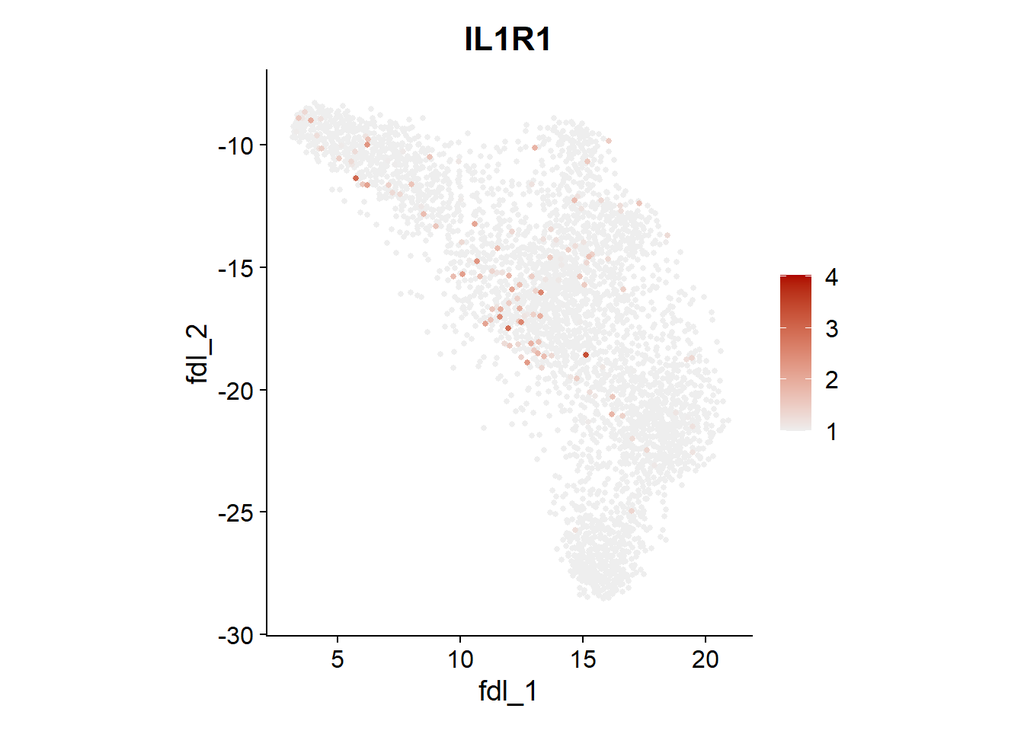

```r
# Set scale common to IL1R1 plots
il1_scale <- scale_color_gradient(
  limits = c(1, 4),
  # colors = c("#EEEEEE", "#AE0600"),
  low = "#EEEEEE",
  high = "#AE0600",
  oob = scales::squish
  )

p5 <- FeaturePlot(pdx_tibia,
  "IL1R1",
  reduction = "fdl",
  pt.size = 1,
  order = TRUE) +
  coord_fixed() +
  il1_scale
p5
```

```r
qs::qsave(pdx_tibia, "output/seurat_objects/pdx_tibia.qs")
rm(pdx_tibia)
```

### Intratumoral Heterogeneity - PDX Lung Met

```r
samples <- tribble(
  ~id, ~model, ~mt_cutoff, ~count_cutoff, ~species,
  "S0281", "OS-17", 25, 160000, "^GRCh38-"
)

s <- 1
pdx_lungs <- tenx_load_qc(
    paste0(pre_path, samples$id[s], post_path),
    species_pattern = samples$species[s],
    violin_plot = FALSE
  ) %>%
  subset(
    percent.mt < samples$mt_cutoff[s] &
    nCount_RNA < samples$count_cutoff[s]
  ) %>%
  NormalizeData()
pdx_lungs$id <- samples$id[s]
pdx_lungs$model <- samples$model[s]

pdx_lungs <- pdx_lungs %>%
  FindVariableFeatures(nfeatures = 5000) %>%
  ScaleData() %>%
  RunPCA()

pdx_lungs <- pdx_lungs %>%
  FindNeighbors(reduction = "pca", k.param = 100L) %>%
  FindClusters(resolution = 0.8) %>%
  RunUMAP(reduction = "pca", dims = 1:30)
```

```
Modularity Optimizer version 1.3.0 by Ludo Waltman and Nees Jan van Eck

Number of nodes: 10994
Number of edges: 1733471

Running Louvain algorithm...
Maximum modularity in 10 random starts: 0.7549
Number of communities: 7
Elapsed time: 4 seconds
```

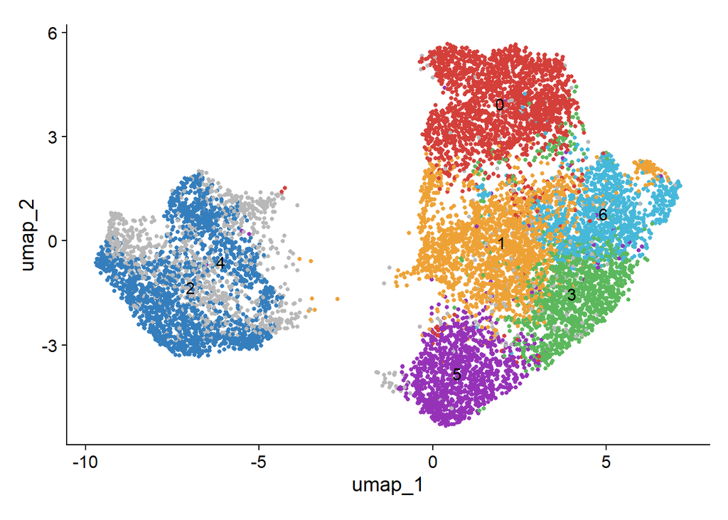

```r
r_dim_plot(pdx_lungs)
```

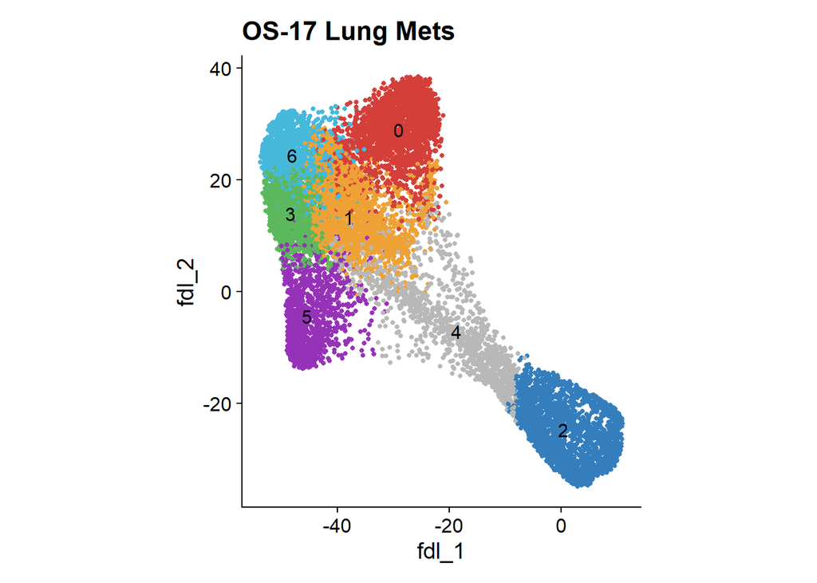

```r
pdx_lungs <- run_fdl(pdx_lungs)

p2 <- r_dim_plot(pdx_lungs, reduction = "fdl") +
  labs(title = "OS-17 Lung Mets")
p2
```

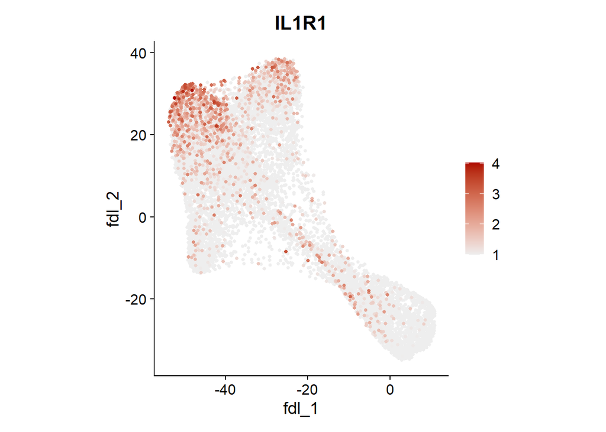

```r
p6 <- FeaturePlot(pdx_lungs,
  "IL1R1",
  reduction = "fdl",
  pt.size = 1,
  order = TRUE) +
  coord_fixed() +
  il1_scale
p6
```

```r
qs::qsave(pdx_lungs, "output/seurat_objects/pdx_lungs.qs")
rm(pdx_lungs)
```

### Intratumoral Heterogeneity - Patient Primary

```r
tumor_cells <- qs::qread("misc/human_os_annotations.qs") %>%
  row.names()

primaries <- qs::qread("output/seurat_objects/human_geo.qs") %>%
  subset(subset = type == "Primary") %>%
  subset(cells = tumor_cells) %>%
  subset(downsample = 10000) %>%
  FindVariableFeatures() %>%
  ScaleData() %>%
  RunPCA() %>%
  harmony::RunHarmony("src") %>%
  RunUMAP(dims = 1:30, reduction = "harmony") %>%
  FindNeighbors(reduction = "harmony") %>%
  FindClusters(resolution = 0.4)
```

```
Modularity Optimizer version 1.3.0 by Ludo Waltman and Nees Jan van Eck

Number of nodes: 10000
Number of edges: 342971

Running Louvain algorithm...
Maximum modularity in 10 random starts: 0.9251
Number of communities: 11
Elapsed time: 0 seconds
```

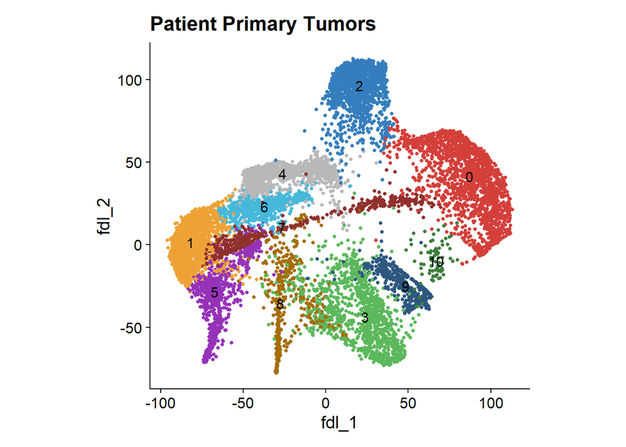

```r
primaries <- run_fdl(primaries)

p3 <- r_dim_plot(primaries, reduction = "fdl") +
  labs(title = "Patient Primary Tumors")
p3
```

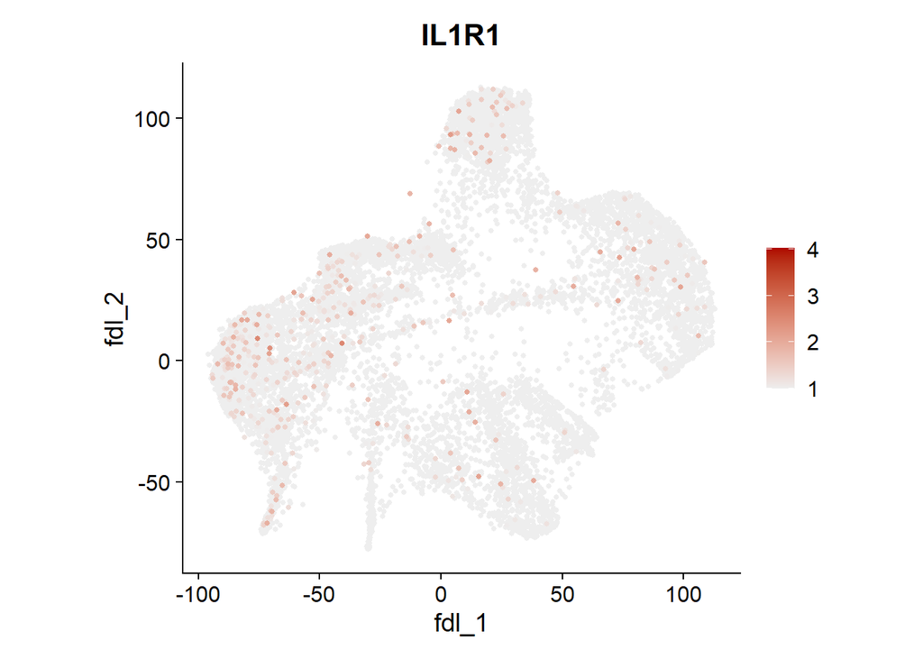

```r
p7 <- FeaturePlot(primaries,
  "IL1R1",
  reduction = "fdl",
  pt.size = 1,
  order = TRUE) +
  coord_fixed() +
  il1_scale
p7
```

```r
qs::qsave(primaries, "output/seurat_objects/primaries.qs")
rm(primaries)
```

### Intratumoral Heterogeneity - Patient Lung Met

```r
# Load tumor cells from the pre-processed patient data
# https://doi.org/10.1158/1078-0432.ccr-24-0049
pt_mets_1 <- qs::qread("public/integrated_lungs.qs") %>%
  subset(subset = met_labels == "Tumor") %>%
  subset(subset = method == "cell")

# And from the GEO dataset downloaded in download.qmd
pt_mets_2 <- qs::qread("output/seurat_objects/human_geo.qs") %>%
  subset(subset = type == "Lung Met") %>%
  subset(cells = tumor_cells)

# Align key metadata
pt_mets_2$id <- pt_mets_2$src
pt_mets_2$src <- "Geo"
pt_mets_2$method <- "cell"

# Merge and downsample
pt_mets_tumor <- merge(pt_mets_1, pt_mets_2) %>%
  JoinLayers() %>%
  subset(downsample = 1200) %>%
  ScaleData() %>%
  FindVariableFeatures(nfeatures = 5000) %>%
  RunPCA()

pt_mets_tumor <- pt_mets_tumor %>%
  harmony::RunHarmony(c("id"),
    dims.use = 1:50,
    theta = 8,
    sigma = .1,
    lambda = .3) %>%
  RunUMAP(dims = 1:50, reduction = "harmony") %>%
  FindNeighbors(reduction = "harmony") %>%
  FindClusters(resolution = 0.4) %>%
  run_fdl()
```

```
Modularity Optimizer version 1.3.0 by Ludo Waltman and Nees Jan van Eck

Number of nodes: 12129
Number of edges: 388980

Running Louvain algorithm...
Maximum modularity in 10 random starts: 0.8976
Number of communities: 11
Elapsed time: 1 seconds
```

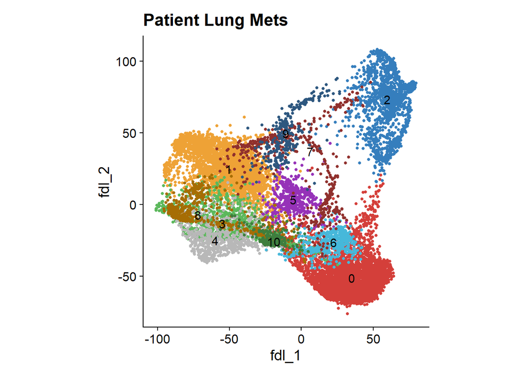

```r
p4 <- r_dim_plot(pt_mets_tumor, reduction = "fdl", order = TRUE) +
  labs(title = "Patient Lung Mets")
p4
```

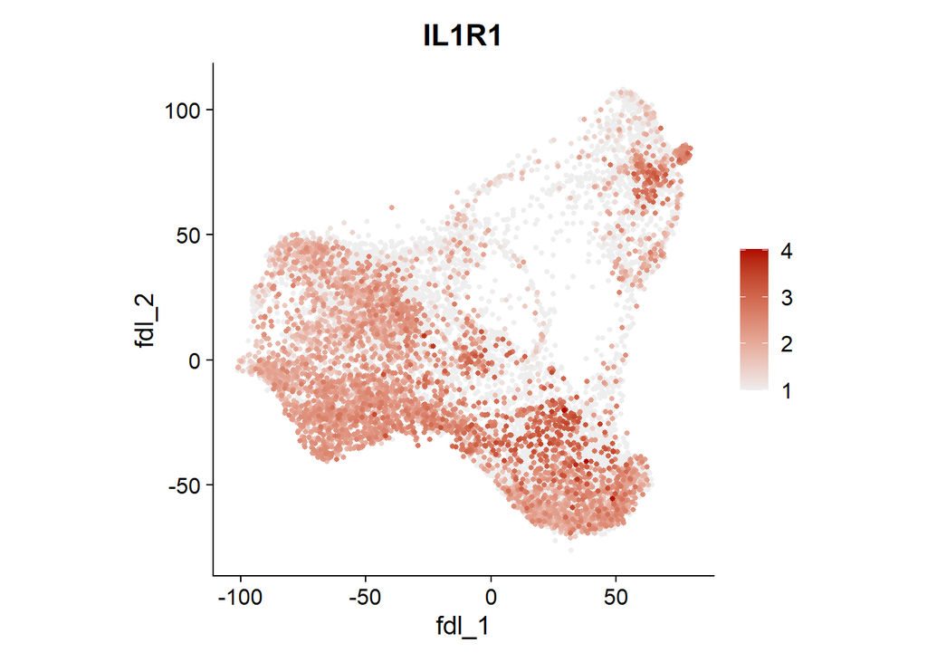

```r
p8 <- FeaturePlot(pt_mets_tumor,
  "IL1R1",
  reduction = "fdl",
  pt.size = 1,
  order = TRUE) +
  coord_fixed() +
  il1_scale
p8
```

```r
qs::qsave(pt_mets_tumor, "output/seurat_objects/pt_mets_tumor.qs")
rm(pt_mets_tumor)
```

### Assemble the figure panel

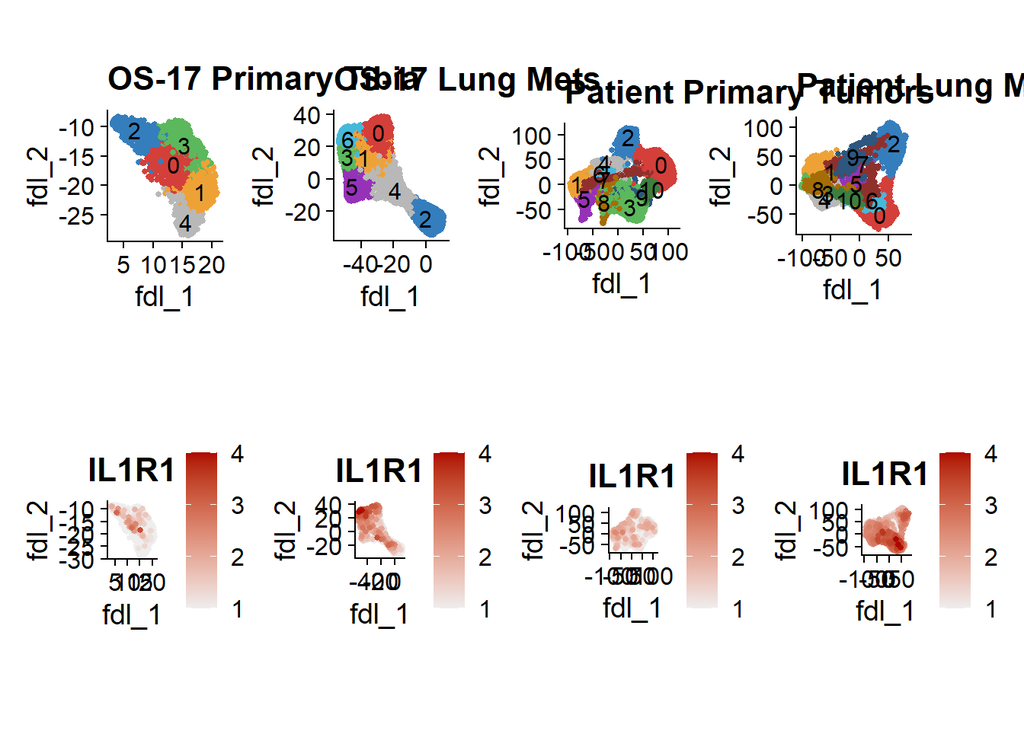

```r
p <- (p1 | p2 | p3 | p4) / (p5 | p6 | p7 | p8)
p
```

```r
stash_plot(p, "Hetero-3")
```

# Brute force optimization of harmony parameters:

```r
pdx_tibia <- qs::qread("output/seurat_objects/pdx_tibia.qs")
pdx_lungs <- qs::qread("output/seurat_objects/pdx_lungs.qs")
primaries <- qs::qread("output/seurat_objects/primaries.qs")
pt_mets_tumor <- qs::qread("output/seurat_objects/pt_mets_tumor.qs")
```

```r
hopts <- tibble(
  theta = c(0.5, 1, 2, 4, 8),
  sigma = c(.01, .03, .1, .3, 1),
  lambda = c(.1, .3, 1, 3, 10)
)
hopts <- expand.grid(hopts$theta, hopts$sigma, hopts$lambda) %>%
  setNames(colnames(hopts))
results <- parallel::mclapply(1:nrow(hopts), function(i) {
  sobj <- pt_mets_tumor %>%
    harmony::RunHarmony("id",
      dims.use = 1:50,
      theta = hopts$theta[i],
      sigma = hopts$sigma[i],
      lambda = hopts$lambda[i]) %>%
    RunUMAP(dims = 1:50, reduction = "harmony") %>%
    FindNeighbors(reduction = "harmony") %>%
    FindClusters(resolution = 0.4)
  return(
    r_dim_plot(sobj,
      group.by = "id",
      order = TRUE,
      ) +
      ggtitle(paste0(
        "Theta ",
        hopts$theta[i],
        ", Sigma ",
        hopts$sigma[i],
        ", Lambda ",
        hopts$lambda[i]
      ))
  )
}, mc.cores = parallelly::availableCores())
format(object.size(results), "Gb")
patchwork::wrap_plots(results[1:25], ncol = 5)
patchwork::wrap_plots(results[26:50], ncol = 5)
patchwork::wrap_plots(results[51:75], ncol = 5)
patchwork::wrap_plots(results[76:100], ncol = 5)
patchwork::wrap_plots(results[101:125], ncol = 5)
```

# IL1-related activity within tumor cells

Here, we evaluate the same transcriptional data for evidence of IL1-driven tumor cell activation, as evidenced by signatures of NF-kB signaling.

## Evaluate pathways downstream of IL1 (NF-kB)

### Evaluate cell cycle and NF-kB - PDX Tibia

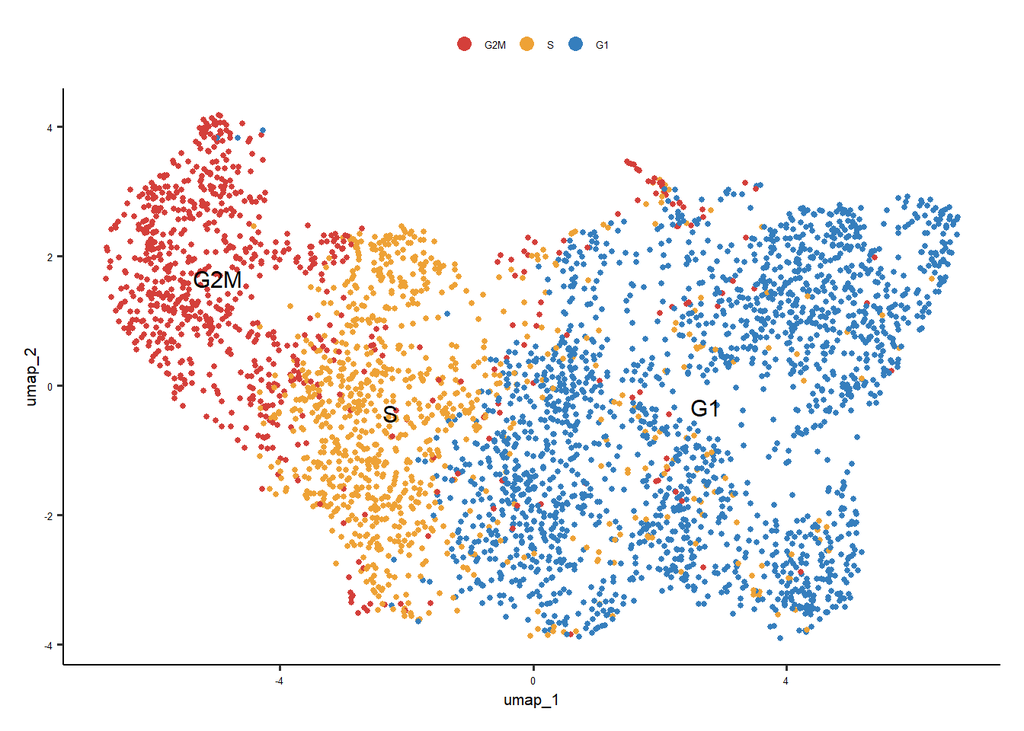

```
[1] "No CC regression performed."
```

```r
# Load the dataset
pdx_tibia <- qs::qread("output/seurat_objects/pdx_tibia.qs")

# Determine cell cycle phase for each cell and plot
pdx_tibia <- kill_cc(pdx_tibia)
```

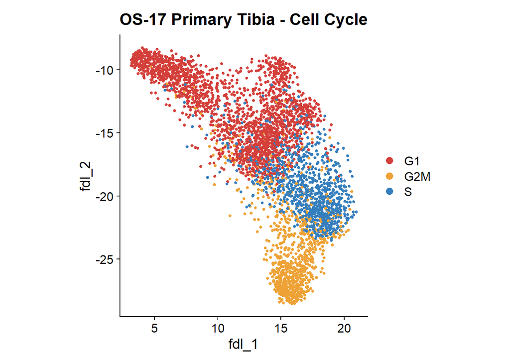

```r
p5 <- r_dim_plot(pdx_tibia,
    reduction = "fdl",
    group.by = "Phase",
    label = FALSE) +
  labs(title = "OS-17 Primary Tibia - Cell Cycle") +
  theme(legend.position = "right")
p5
```

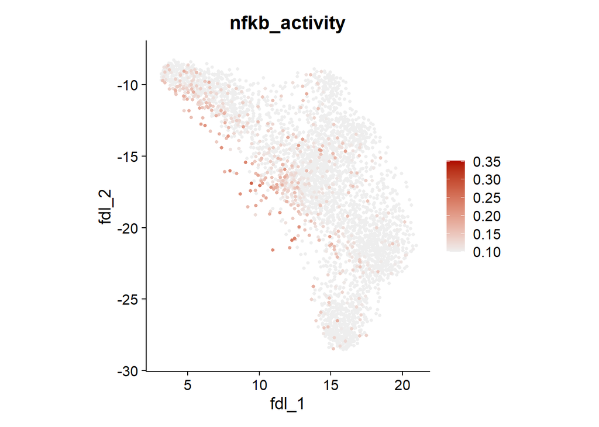

```r
# Pull the transcription-factor regulated gene sets from msigdb
sigs <- msigdbr::msigdbr(species = "Homo sapiens",
    category = "H") %>%
  select(gs_name, gene_symbol)

gs <- "HALLMARK_TNFA_SIGNALING_VIA_NFKB"

# Quantify the NF-kB pathway activity and plot
cell_ranks <- AUCell::AUCell_run(
  pdx_tibia[["RNA"]]$counts,
  sigs %>% filter(gs_name == gs) %>% pull(gene_symbol)
)
pdx_tibia$nfkb_activity <- AUCell::getAUC(cell_ranks)[1,]

# Set scale common to IL1R1 plots
nfkb_scale <- scale_color_gradient(
  limits = c(0.1, 0.35),
  # colors = c("#EEEEEE", "#AE0600"),
  low = "#EEEEEE",
  high = "#AE0600",
  oob = scales::squish
  )

p1 <- FeaturePlot(pdx_tibia,
  "nfkb_activity",
  reduction = "fdl",
  pt.size = 1,
  order = TRUE) +
  coord_fixed() +
  nfkb_scale
p1
```

### Evaluate cell cycle and NF-kB - PDX Lung Mets

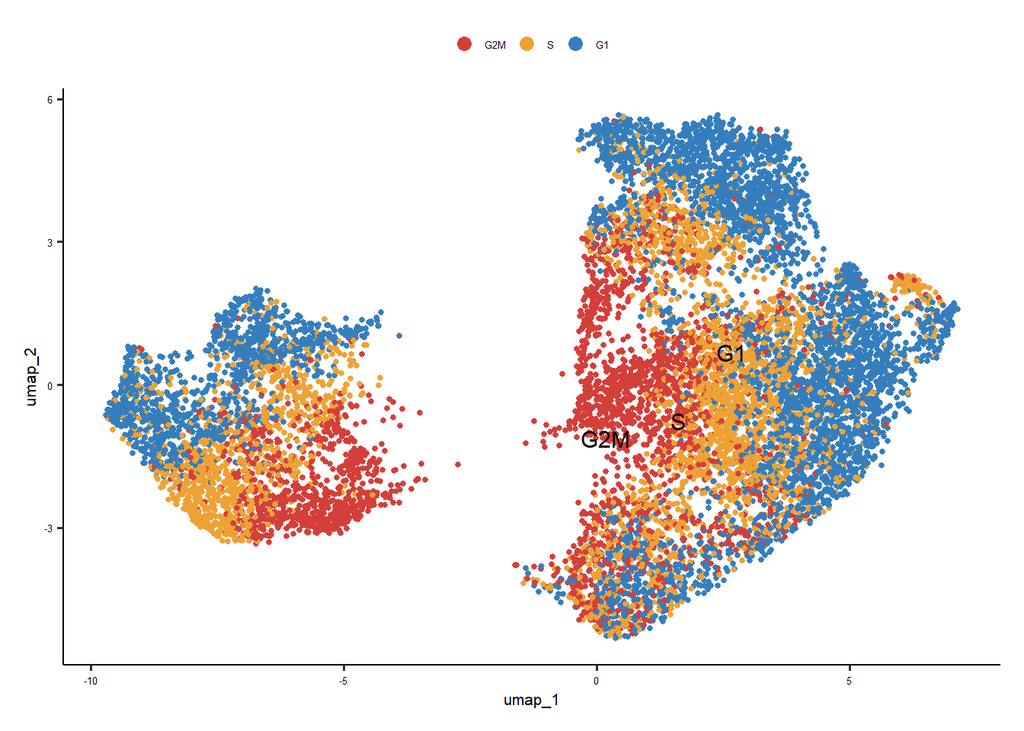

```
[1] "No CC regression performed."
```

```r
# Load the dataset
pdx_lungs <- qs::qread("output/seurat_objects/pdx_lungs.qs")

# Determine cell cycle phase for each cell and plot
pdx_lungs <- kill_cc(pdx_lungs)
```

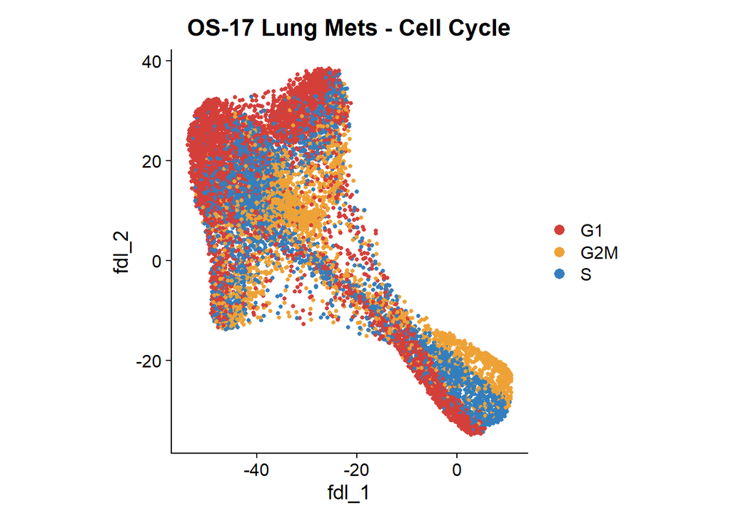

```r
p6 <- r_dim_plot(pdx_lungs,
    reduction = "fdl",
    group.by = "Phase",
    label = FALSE) +
  labs(title = "OS-17 Lung Mets - Cell Cycle") +
  theme(legend.position = "right")
p6
```

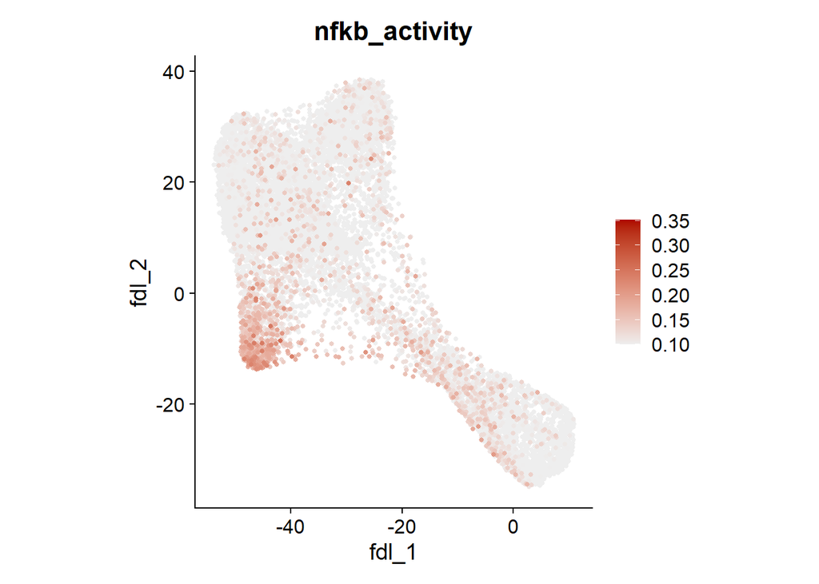

```r
# Quantify the NF-kB pathway activity and plot
cell_ranks <- AUCell::AUCell_run(
  pdx_lungs[["RNA"]]$counts,
  sigs %>% filter(gs_name == gs) %>% pull(gene_symbol)
)
pdx_lungs$nfkb_activity <- AUCell::getAUC(cell_ranks)[1,]

p2 <- FeaturePlot(pdx_lungs,
  "nfkb_activity",
  reduction = "fdl",
  pt.size = 1,
  order = TRUE) +
  coord_fixed() +
  nfkb_scale
p2
```